# Customer Chun Project

ConnectTel is a leading telecommunications company at the forefront of innovation and connectivity solutions With a strong presence in the global market, ConnectTel has established itself as a trusted provider of reliable voice, data, and Internet services Offering a comprehensive range of telecommunications solutions, including mobile networks, broadband connections, and enterprise solutions

ConnectTel Telecom Company faces the pressing need to address customer churn, which poses a significant threat to its business sustainability and growth The company's current customer retention strategies lack precision and effectiveness, resulting in the loss of valuable customers to competitors To overcome this challenge, ConnectTel aims to develop a robust customer churn prediction system for which you have been contacted to handle as a Data Scientist By leveraging advanced analytics and machine learning techniques on available customer data, the company seeks to accurately forecast customer churn and implement targeted retention initiatives

```python
#Importing all my necessary libraries for data analysis

import numpy as np #data analysis
import pandas as pd #data analysis

import matplotlib.pyplot as plt #data visualisation
%matplotlib inline
import seaborn as sns #data visualisation
import missingno as msno # Missing data-#data visualisation
from collections import Counter # Counting use capital C
```

```python
df = pd.read_csv(r"C:\Users\22077\OneDrive - London School of Hygiene and Tropical Medicine\Documents\10Alytics\customer_chun.csv")
df.head()
```

|  | customerID | gender | SeniorCitizen | Partner | Dependents | tenure | PhoneService | MultipleLines | InternetService | OnlineSecurity | ... | DeviceProtection | TechSupport | StreamingTV | StreamingMovies | Contract | PaperlessBilling | PaymentMethod | MonthlyCharges | TotalCharges | Churn |
| --- | --- | --- | --- | --- | --- | --- | --- | --- | --- | --- | --- | --- | --- | --- | --- | --- | --- | --- | --- | --- | --- |
| 0 | 7590-VHVEG | Female | 0 | Yes | No | 1 | No | No phone service | DSL | No | ... | No | No | No | No | Month-to-month | Yes | Electronic check | 29.85 | 29.85 | No |
| 1 | 5575-GNVDE | Male | 0 | No | No | 34 | Yes | No | DSL | Yes | ... | Yes | No | No | No | One year | No | Mailed check | 56.95 | 1889.5 | No |
| 2 | 3668-QPYBK | Male | 0 | No | No | 2 | Yes | No | DSL | Yes | ... | No | No | No | No | Month-to-month | Yes | Mailed check | 53.85 | 108.15 | Yes |
| 3 | 7795-CFOCW | Male | 0 | No | No | 45 | No | No phone service | DSL | Yes | ... | Yes | Yes | No | No | One year | No | Bank transfer (automatic) | 42.30 | 1840.75 | No |
| 4 | 9237-HQITU | Female | 0 | No | No | 2 | Yes | No | Fiber optic | No | ... | No | No | No | No | Month-to-month | Yes | Electronic check | 70.70 | 151.65 | Yes |

5 rows × 21 columns

## Data Cleaning and Pre-processing

```python
# I want to view all info of the features
df.info()
```

```
<class 'pandas.core.frame.DataFrame'>
RangeIndex: 7043 entries, 0 to 7042
Data columns (total 21 columns):
 #   Column            Non-Null Count  Dtype
---  ------            --------------  -----
 0   customerID        7043 non-null   object
 1   gender            7043 non-null   object
 2   SeniorCitizen     7043 non-null   int64
 3   Partner           7043 non-null   object
 4   Dependents        7043 non-null   object
 5   tenure            7043 non-null   int64
 6   PhoneService      7043 non-null   object
 7   MultipleLines     7043 non-null   object
 8   InternetService   7043 non-null   object
 9   OnlineSecurity    7043 non-null   object
 10  OnlineBackup      7043 non-null   object
 11  DeviceProtection  7043 non-null   object
 12  TechSupport       7043 non-null   object
 13  StreamingTV       7043 non-null   object
 14  StreamingMovies   7043 non-null   object
 15  Contract          7043 non-null   object
 16  PaperlessBilling  7043 non-null   object
 17  PaymentMethod     7043 non-null   object
 18  MonthlyCharges    7043 non-null   float64
 19  TotalCharges      7043 non-null   object
 20  Churn             7043 non-null   object
dtypes: float64(1), int64(2), object(18)
memory usage: 1.1+ MB
```

```python
df.isnull().sum()
```

```
customerID          0
gender              0
SeniorCitizen       0
Partner             0
Dependents          0
tenure              0
PhoneService        0
MultipleLines       0
InternetService     0
OnlineSecurity      0
OnlineBackup        0
DeviceProtection    0
TechSupport         0
StreamingTV         0
StreamingMovies     0
Contract            0
PaperlessBilling    0
PaymentMethod       0
MonthlyCharges      0
TotalCharges        0
Churn               0
dtype: int64
```

```python
# no null values
```

```python
df.columns.tolist()
```

```
['customerID',
 'gender',
 'SeniorCitizen',
 'Partner',
 'Dependents',
 'tenure',
 'PhoneService',
 'MultipleLines',
 'InternetService',
 'OnlineSecurity',
 'OnlineBackup',
 'DeviceProtection',
 'TechSupport',
 'StreamingTV',
 'StreamingMovies',
 'Contract',
 'PaperlessBilling',
 'PaymentMethod',
 'MonthlyCharges',
 'TotalCharges',
 'Churn']
```

```python
#quick staistical analysis

df.describe()
```

|  | SeniorCitizen | tenure | MonthlyCharges |
| --- | --- | --- | --- |
| count | 7043.000000 | 7043.000000 | 7043.000000 |
| mean | 0.162147 | 32.371149 | 64.761692 |
| std | 0.368612 | 24.559481 | 30.090047 |
| min | 0.000000 | 0.000000 | 18.250000 |
| 25% | 0.000000 | 9.000000 | 35.500000 |
| 50% | 0.000000 | 29.000000 | 70.350000 |
| 75% | 0.000000 | 55.000000 | 89.850000 |
| max | 1.000000 | 72.000000 | 118.750000 |

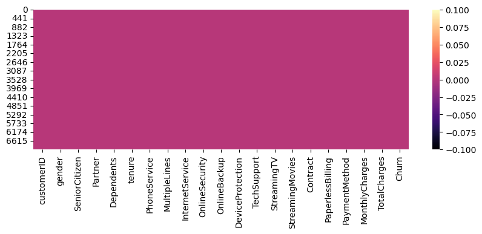

```python
#Plotting a heat map for missing variables

#df.isnull().sum() # you can also use df.isna().sum()
#print (df.isnull().sum())

#visuliasing the missing data

plt.figure(figsize = (10,3))

sns.heatmap(df.isnull(), cbar = True, cmap = 'magma')
```

```python
# I am generating a corr matrix for correlation
corr_matrix =  df.corr()
```

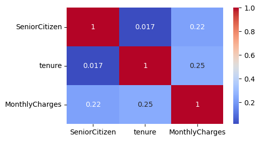

```python
## plotting the correlation or relationship between each parameter of the character or column

plt.figure(figsize = (5,3))

sns.heatmap(corr_matrix, cmap='coolwarm', annot=True, cbar=True)
```

Note that this is a preliminary correlation. See below for a better correlation

```python
df.duplicated().sum()
```

```
0
```

```python
# Let us look at the unique values of two features

df['InternetService'].unique()
```

```
array(['DSL', 'Fiber optic', 'No'], dtype=object)
```

```python
df['PaymentMethod'].unique()
```

```
array(['Electronic check', 'Mailed check', 'Bank transfer (automatic)',
       'Credit card (automatic)'], dtype=object)
```

```python
# I am changing the "Bank Transfer (automatic)" to 'bank transfer' for easy call

df['PaymentMethod'] = df['PaymentMethod'].str.replace('Bank transfer \(automatic\)', 'bank transfer', regex=True)
```

```python
# I am changing the "Bank Transfer (automatic)" to 'bank transfer' for easy call

df['PaymentMethod'] = df['PaymentMethod'].str.replace('Credit card \(automatic\)', 'credit card', regex=True)
```

```python
df['PaymentMethod'].unique()
```

```
array(['Electronic check', 'Mailed check', 'bank transfer', 'credit card'],
      dtype=object)
```

# The data is set for exploration

## Exploratory Data Analysis to have a descriptive excellent insight into the Telecommunication data.

### Univariate analysis

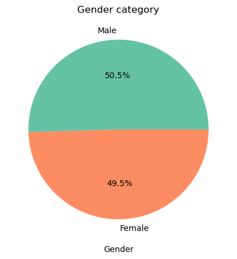

```python
# i am using a pie chart for the gender

plt.figure(figsize=(8, 5))

# Calculate the count of each gender category
gender_counts = df['gender'].value_counts()

# Create the pie chart with percentages
plt.pie(gender_counts, labels=gender_counts.index, autopct='%1.1f%%', colors=sns.color_palette('Set2'))
plt.xlabel("Gender")
plt.title('Gender category')

plt.show()
```

The is a slight gender difference with more male than female

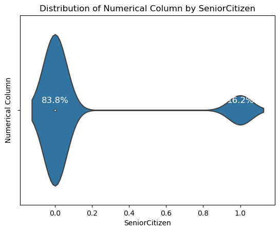

```python
# let us look at the senior citizen category

# Create a violin chart
ax = sns.violinplot(data=df, x='SeniorCitizen', palatte = 'red')

# Calculate the percentage of data points in each category
total_count = len(df)
percentages = df['SeniorCitizen'].value_counts(normalize=True) * 100

# Annotate the violin plot with percentage labels
for i, (cat, percent) in enumerate(zip(percentages.index, percentages)):
    ax.annotate(f'{percent:.1f}%', xy=(i, 0), xytext=(0,10), textcoords='offset points', ha='center', fontsize=12, color='white')

# Set labels and title
plt.xlabel("SeniorCitizen")
plt.ylabel("Numerical Column")
plt.title('Distribution of Numerical Column by SeniorCitizen')

plt.show()
```

There is a significant difference here. Majority (83%) of the customers are NOT senior citizens

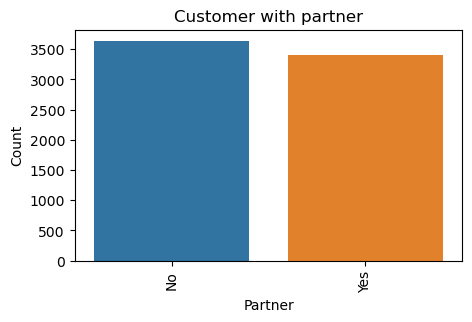

```python
# I am plotting a sublot for six features asa a univariate analysis.

# Visualising the data based on the payment method

plt.figure(figsize=(5, 3))

# Calculate the count of each payment method and sort in descending order
partner_counts = df['Partner'].value_counts()
partner_order = partner_counts.index

sns.countplot(x='Partner', data=df, order=partner_order)
plt.xlabel("Partner")
plt.ylabel('Count')
plt.title('Customer with partner')
plt.xticks(rotation=90)
plt.show()

#total = len(df['Partner'])
#for p in ax.patches:
    #height = p.get_height()
    #ax.annotate(f'{(height / total) * 100:.1f}%',
               # (p.get_x() + p.get_width() / 2., height),
               # ha='center', va='bottom', fontsize=10)
```

[figure not shown]

```python
# I am checking four columns

# Create a 2x2 grid for subplots
fig, axs = plt.subplots(2, 2, figsize=(20, 15))

# Plot the data on each subplot
plt1 = sns.countplot(x=df['Dependents'], ax=axs[0, 0])
axs[0, 0].set_title('Customer')

plt2 = sns.countplot(x=df['OnlineSecurity'], ax=axs[0, 1])
axs[0, 1].set_title('OnlineSecurity')

plt3 = sns.countplot(x=df['StreamingMovies'], ax=axs[1, 0])
axs[1, 0].set_title('DeviceProtection')

plt4 = sns.countplot(x=df['StreamingTV'], ax=axs[1, 1])
axs[1, 1].set_title('StreamingTV')

plt.tight_layout()
```

```python
# Change Total Charges to Float from Object


# Remove non-numeric characters and convert to float
#df['TotalCharges'] = df['TotalCharges'].str.replace('[^\d.]', '', regex=True).astype(float)
#df['TotalCharges'] = df['TotalCharges'].astype('float')
# Now 'TotalCharges' is a float column
#print(df.dtypes)
#df.isNaN()

df['TotalCharges'] = df['TotalCharges'].str.replace('[^\d.]', '', regex=True)
df['TotalCharges'] = pd.to_numeric(df['TotalCharges'], errors='coerce')
```

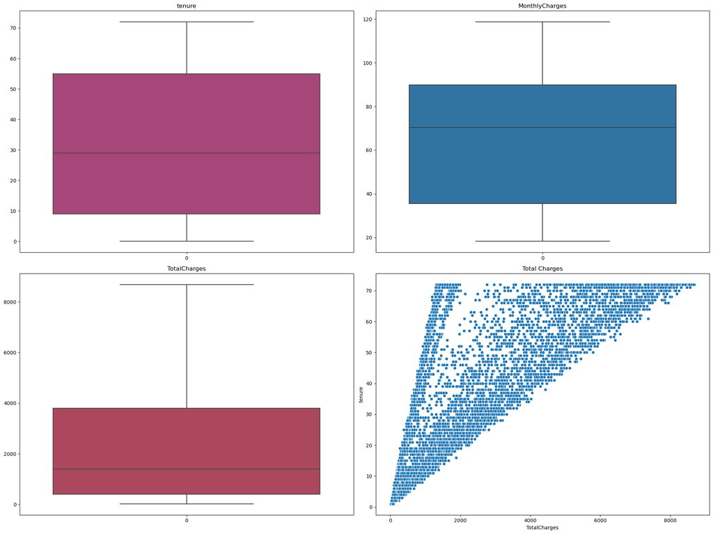

```python
# I am checking four columns

# Create a 2x2 grid for subplots
fig, axs = plt.subplots(2, 2, figsize=(20, 15))

# Plot the data on each subplot
plt1 = sns.boxplot(df['tenure'], ax=axs[0, 0], palette='magma')
axs[0, 0].set_title('tenure')

plt2 = sns.boxplot(df['MonthlyCharges'], ax=axs[0, 1])
axs[0, 1].set_title('MonthlyCharges')

plt3 = sns.boxplot(df['TotalCharges'], ax=axs[1, 0], palette='inferno')
axs[1, 0].set_title('TotalCharges')

plt4 = sns.scatterplot(x='TotalCharges', y='tenure', data=df, ax=axs[1, 1])
axs[1, 1].set_title('Total Charges')

plt.tight_layout()
```

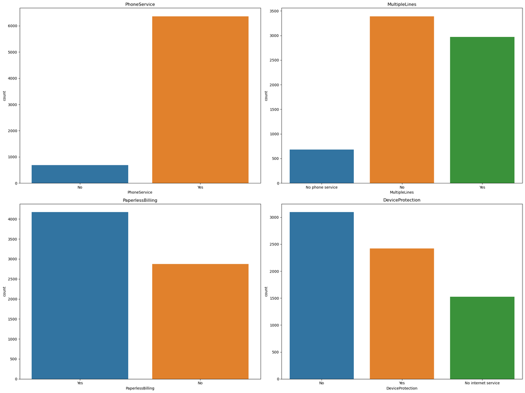

```python
# I am checking four columns

# Create a 2x2 grid for subplots
fig, axs = plt.subplots(2, 2, figsize=(20, 15))

# Plot the data on each subplot
plt1 = sns.countplot(x=df['PhoneService'], ax=axs[0, 0])
axs[0, 0].set_title('PhoneService')

plt2 = sns.countplot(x=df['MultipleLines'], ax=axs[0, 1])
axs[0, 1].set_title('MultipleLines')

plt3 = sns.countplot(x=df['PaperlessBilling'], ax=axs[1, 0])
axs[1, 0].set_title('PaperlessBilling')

plt4 = sns.countplot(x=df['DeviceProtection'], ax=axs[1, 1])
axs[1, 1].set_title('DeviceProtection')

plt.tight_layout()
```

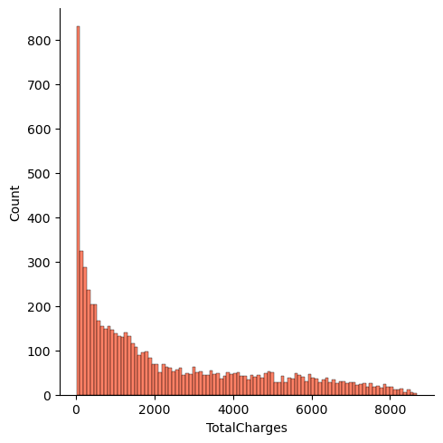

```python
sns.displot(df['TotalCharges'], bins =100, color = '#FF5733')
```

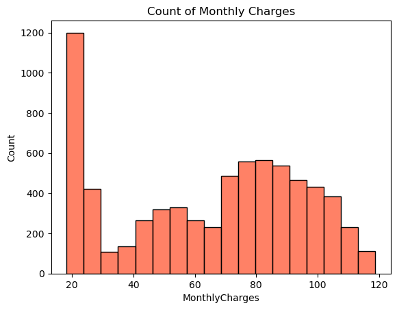

```python
#I am using a histogram to plot a univariate of Monthly cahrges
sns.histplot(df['MonthlyCharges'], color= '#FF5733')
plt.title('Count of Monthly Charges')
plt.show()
```

### Bivariate Analysis

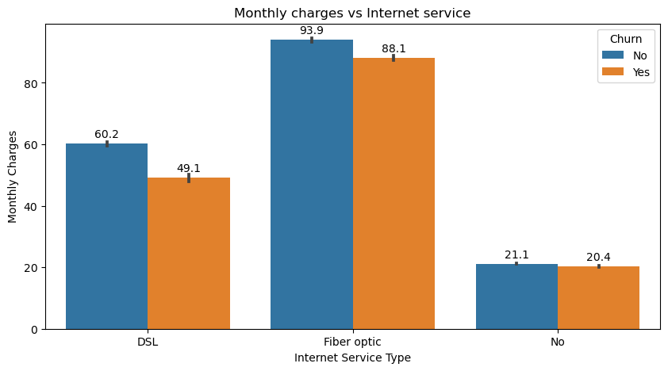

```python
plt.figure(figsize = (10,5))

ax = sns.barplot(x='InternetService', data=df, y= 'MonthlyCharges', hue = 'Churn')
plt.xlabel("Internet Service Type")
plt.ylabel('Monthly Charges')
plt.title('Monthly charges vs Internet service')

#to show the number on the bar
# Adding the numbers on top of the bars
for p in ax.patches:
    height = p.get_height()
    ax.text(p.get_x() + p.get_width() / 2., height + 2, f'{height:.1f}', ha="center")

plt.show()
```

```python
df['MultipleLines'].unique()
```

```
array(['No phone service', 'No', 'Yes'], dtype=object)
```

```
Fiber optic    3096
DSL            2421
No             1526
Name: InternetService, dtype: int64
```

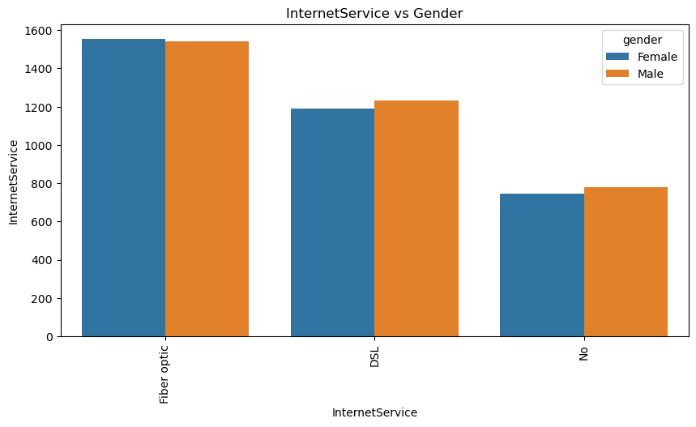

```python
# Let us consider the gender, partner and senior citizens


print (df['InternetService'].value_counts())

Internet_counts = df['InternetService'].value_counts()
Internet_order = Internet_counts.index

plt.figure(figsize = (10,5))

sns.countplot(x='InternetService', data=df, hue='gender', order = Internet_order)
plt.xlabel("InternetService")
plt.ylabel('InternetService')
plt.title('InternetService vs Gender')
plt.xticks(rotation=90)
plt.show();
```

```
No                  3390
Yes                 2971
No phone service     682
Name: MultipleLines, dtype: int64
Electronic check    2365
Mailed check        1612
bank transfer       1544
credit card         1522
Name: PaymentMethod, dtype: int64
Fiber optic    3096
DSL            2421
No             1526
Name: InternetService, dtype: int64
Fiber optic    3096
DSL            2421
No             1526
Name: InternetService, dtype: int64
```

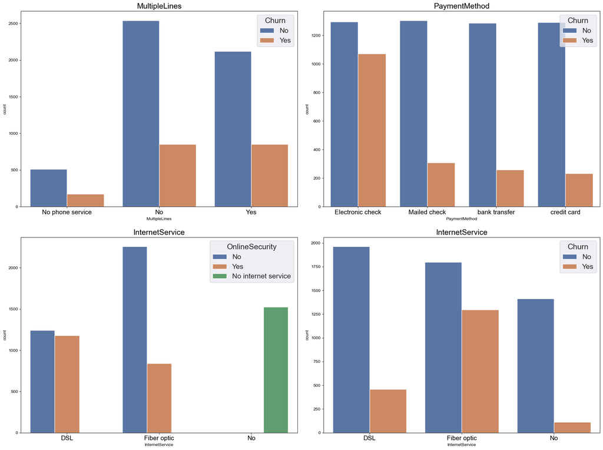

```python
# Create a 2x2 grid for subplots

fig, axs1 = plt.subplots(2, 2, figsize=(20, 15))

sns.set(font_scale=1.5) # to increase the font size of the hue

plt5 = sns.countplot(x='MultipleLines', hue='Churn', data=df, ax=axs1[0,0])
axs1[0,0].set_title('MultipleLines')
plt5.tick_params(axis='x', labelsize=15) #to increase the font size of the labels
print(df['MultipleLines'].value_counts())

plt6 = sns.countplot(x='PaymentMethod', hue='Churn', data=df, ax=axs1[0,1])
axs1[0,1].set_title('PaymentMethod')
plt6.tick_params(axis='x', labelsize=15)
print(df['PaymentMethod'].value_counts())

plt7 = sns.countplot(x='InternetService', hue='OnlineSecurity', data=df, ax=axs1[1,0])
axs1[1,0].set_title('InternetService')
plt7.tick_params(axis='x', labelsize=15)
print(df['InternetService'].value_counts())

plt8 = sns.countplot(x='InternetService', hue='Churn', data=df, ax=axs1[1,1])
axs1[1,1].set_title('InternetService')
plt8.tick_params(axis='x', labelsize=15)
print(df['InternetService'].value_counts())


plt.tight_layout()
plt.show()
```

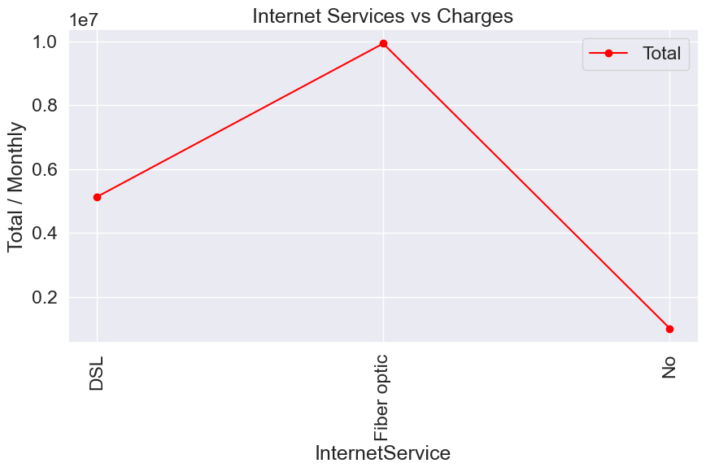

```python
# Visualise the monthly charges and total for internet services

int_counts = df['InternetService'].value_counts()
int_order = int_counts.index

plt.figure(figsize=(10, 5))

# Line graph for 'Montly Charges'
#plt.plot(df.groupby('InternetService')['MonthlyCharges'].sum(), color='blue', marker='o', label='Month')

# Line graph for 'Total Charges'
plt.plot(df.groupby('InternetService')['TotalCharges'].sum(), color='red', marker='o', label='Total')

# Set x-axis and y-axis labels
plt.xlabel("InternetService")
plt.ylabel('Total / Monthly')
plt.title('Internet Services vs Charges')
plt.xticks(rotation=90)

# Display the legend
plt.legend(loc='upper right')

plt.show()
```

```
Month-to-month    3875
Two year          1695
One year          1473
Name: Contract, dtype: int64
```

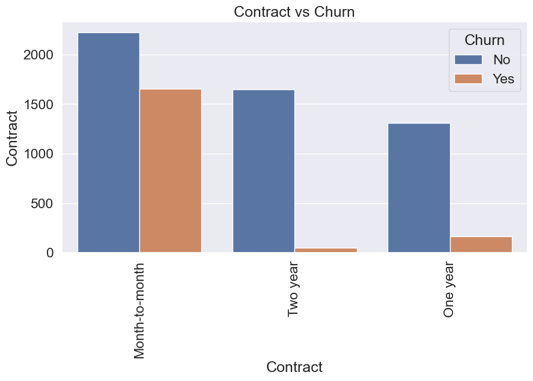

```python
# Let us consider the gender, partner and senior citizens


print (df['Contract'].value_counts())

Contract_counts = df['Contract'].value_counts()
Contract_order = Contract_counts.index

plt.figure(figsize = (10,5))

sns.countplot(x='Contract', data=df, hue='Churn', order = Contract_order)
plt.xlabel("Contract")
plt.ylabel('Contract')
plt.title('Contract vs Churn')
plt.xticks(rotation=90)
plt.show();
```

Those that churn more are those with monthly contract

```python
df['MonthlyCharges'].max()
```

```
118.75
```

```python
df['MonthlyCharges'].min()
```

```
18.25
```

```python
# I am going to group Monthtly charges and Total Charges in to five groups for further analysis.


def monthly_group(mcharges):
    if mcharges <= 40:
        return 'low chg (<40)'
    elif mcharges <= 60:
        return 'middle chg (<60)'
    elif mcharges <= 80:
        return 'high chg (<80)'
    elif mcharges <= 100:
        return 'huge (< 100)'
    else:
        return 'mammoth'

df['monthly_group'] = df['MonthlyCharges'].apply(monthly_group)
```

```
low chg (<40)       1838
huge (< 100)        1764
high chg (<80)      1459
middle chg (<60)    1080
mammoth              902
Name: monthly_group, dtype: int64
low chg (<40)       1838
huge (< 100)        1764
high chg (<80)      1459
middle chg (<60)    1080
mammoth              902
Name: monthly_group, dtype: int64
```

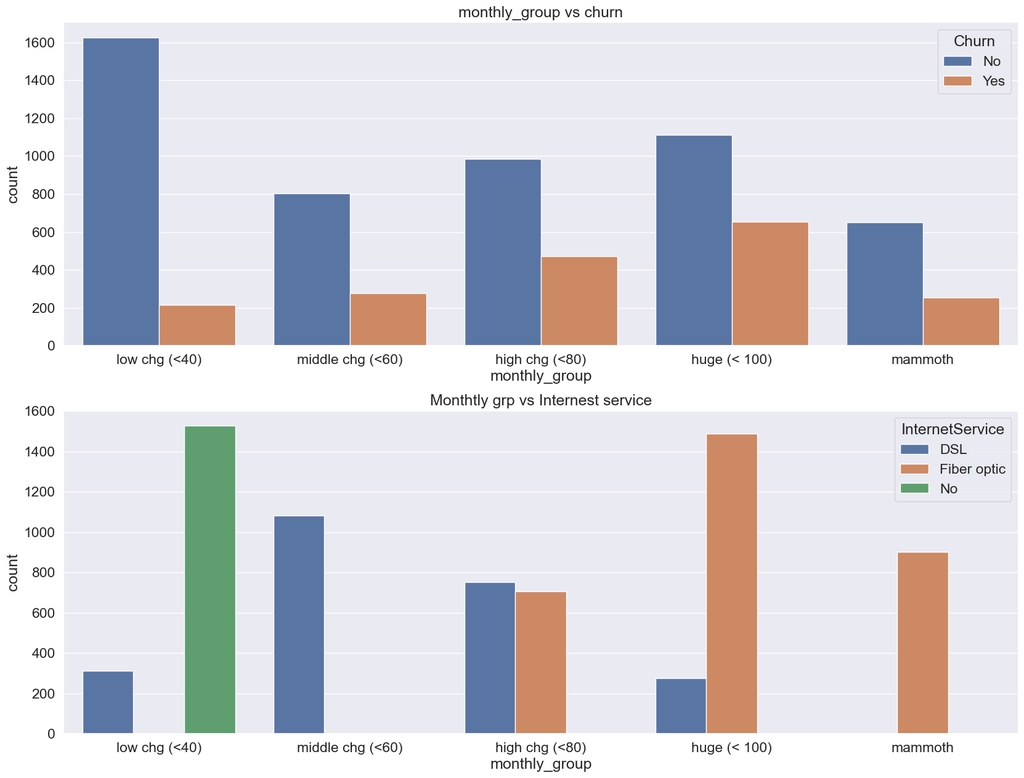

```python
# Create a 1x1 grid for subplots

fig, axs2 = plt.subplots(2, 1, figsize=(20, 15))

#sns.set(font_scale=1.5) # to increase the font size of the hue

plt9 = sns.countplot(x='monthly_group', hue='Churn', data=df, ax=axs2[0])
axs2[0].set_title('monthly_group vs churn')
plt5.tick_params(axis='x', labelsize=15) #to increase the font size of the labels
print(df['monthly_group'].value_counts())

plt10 = sns.countplot(x='monthly_group', hue='InternetService', data=df, ax=axs2[1])
axs2[1].set_title('Monthtly grp vs Internest service')
plt6.tick_params(axis='x', labelsize=15)
print(df['monthly_group'].value_counts())
```

```python
df['InternetService'].unique()
```

```
array(['DSL', 'Fiber optic', 'No'], dtype=object)
```

#### I am changing all actegorical variables into numerical for the purpose of Multivariate analysis and ML

###### I am importing another library called LabelEncoder from sklearn

```python
df1 = df[['gender', 'Partner', 'Dependents', 'PhoneService', 'MultipleLines', 'InternetService', 'OnlineSecurity', 'TechSupport', 'StreamingTV', 'StreamingMovies', 'Contract', 'PaperlessBilling', 'PaymentMethod', 'Churn' ]]
```

```python
# Label encoding #Get dummy variables makes it more difficult, hence I use label encoder more

from sklearn.preprocessing import LabelEncoder
```

###### I changed my categorical values to numerical

```python
# Changing my categorical variables to numerical variables

encoder = LabelEncoder() # method initialisation

# Looping for columns except columns with int or float

for c in df1.columns[0:]: #it is indexing the column one after the other, rather than using data1.column()
    if (df1[c].dtype == 'object'):
        df1[c] = encoder.fit_transform(df1[c])
    else:
        df1[c] = df1[c]


df1.head()
```

[output not shown]

[output cut: 29 more lines]

[output not shown]

|  | gender | Partner | Dependents | PhoneService | MultipleLines | InternetService | OnlineSecurity | TechSupport | StreamingTV | StreamingMovies | Contract | PaperlessBilling | PaymentMethod | Churn |
| --- | --- | --- | --- | --- | --- | --- | --- | --- | --- | --- | --- | --- | --- | --- |
| 0 | 0 | 1 | 0 | 0 | 1 | 0 | 0 | 0 | 0 | 0 | 0 | 1 | 0 | 0 |
| 1 | 1 | 0 | 0 | 1 | 0 | 0 | 2 | 0 | 0 | 0 | 1 | 0 | 1 | 0 |
| 2 | 1 | 0 | 0 | 1 | 0 | 0 | 2 | 0 | 0 | 0 | 0 | 1 | 1 | 1 |
| 3 | 1 | 0 | 0 | 0 | 1 | 0 | 2 | 2 | 0 | 0 | 1 | 0 | 2 | 0 |
| 4 | 0 | 0 | 0 | 1 | 0 | 1 | 0 | 0 | 0 | 0 | 0 | 1 | 0 | 1 |

```python
# Now we do our correlation again for multivariate analysis.
```

```python
df1.corr()
```

|  | gender | Partner | Dependents | PhoneService | MultipleLines | InternetService | OnlineSecurity | TechSupport | StreamingTV | StreamingMovies | Contract | PaperlessBilling | PaymentMethod | Churn |
| --- | --- | --- | --- | --- | --- | --- | --- | --- | --- | --- | --- | --- | --- | --- |
| gender | 1.000000 | -0.001808 | 0.010517 | -0.006488 | -0.006739 | -0.000863 | -0.015017 | -0.006825 | -0.006421 | -0.008743 | 0.000126 | -0.011754 | -0.005209 | -0.008612 |
| Partner | -0.001808 | 1.000000 | 0.452676 | 0.017706 | 0.142410 | 0.000891 | 0.150828 | 0.126733 | 0.137341 | 0.129574 | 0.294806 | -0.014877 | 0.133115 | -0.150448 |
| Dependents | 0.010517 | 0.452676 | 1.000000 | -0.001762 | -0.024991 | 0.044590 | 0.152166 | 0.133524 | 0.046885 | 0.021321 | 0.243187 | -0.111377 | 0.123844 | -0.164221 |
| PhoneService | -0.006488 | 0.017706 | -0.001762 | 1.000000 | -0.020538 | 0.387436 | -0.015198 | -0.019158 | 0.055353 | 0.043870 | 0.002247 | 0.016505 | -0.004070 | 0.011942 |
| MultipleLines | -0.006739 | 0.142410 | -0.024991 | -0.020538 | 1.000000 | -0.109216 | 0.007141 | 0.011466 | 0.175059 | 0.180957 | 0.110842 | 0.165146 | 0.038603 | 0.038037 |
| InternetService | -0.000863 | 0.000891 | 0.044590 | 0.387436 | -0.109216 | 1.000000 | -0.028416 | -0.026047 | 0.107417 | 0.098350 | 0.099721 | -0.138625 | 0.008124 | -0.047291 |
| OnlineSecurity | -0.015017 | 0.150828 | 0.152166 | -0.015198 | 0.007141 | -0.028416 | 1.000000 | 0.285028 | 0.044669 | 0.055954 | 0.374416 | -0.157641 | 0.227956 | -0.289309 |
| TechSupport | -0.006825 | 0.126733 | 0.133524 | -0.019158 | 0.011466 | -0.026047 | 0.285028 | 1.000000 | 0.161305 | 0.161316 | 0.425367 | -0.113600 | 0.232702 | -0.282492 |
| StreamingTV | -0.006421 | 0.137341 | 0.046885 | 0.055353 | 0.175059 | 0.107417 | 0.044669 | 0.161305 | 1.000000 | 0.434772 | 0.227116 | 0.096642 | 0.039316 | -0.036581 |
| StreamingMovies | -0.008743 | 0.129574 | 0.021321 | 0.043870 | 0.180957 | 0.098350 | 0.055954 | 0.161316 | 0.434772 | 1.000000 | 0.231226 | 0.083700 | 0.049676 | -0.038492 |
| Contract | 0.000126 | 0.294806 | 0.243187 | 0.002247 | 0.110842 | 0.099721 | 0.374416 | 0.425367 | 0.227116 | 0.231226 | 1.000000 | -0.176733 | 0.358913 | -0.396713 |
| PaperlessBilling | -0.011754 | -0.014877 | -0.111377 | 0.016505 | 0.165146 | -0.138625 | -0.157641 | -0.113600 | 0.096642 | 0.083700 | -0.176733 | 1.000000 | -0.101480 | 0.191825 |
| PaymentMethod | -0.005209 | 0.133115 | 0.123844 | -0.004070 | 0.038603 | 0.008124 | 0.227956 | 0.232702 | 0.039316 | 0.049676 | 0.358913 | -0.101480 | 1.000000 | -0.262818 |
| Churn | -0.008612 | -0.150448 | -0.164221 | 0.011942 | 0.038037 | -0.047291 | -0.289309 | -0.282492 | -0.036581 | -0.038492 | -0.396713 | 0.191825 | -0.262818 | 1.000000 |

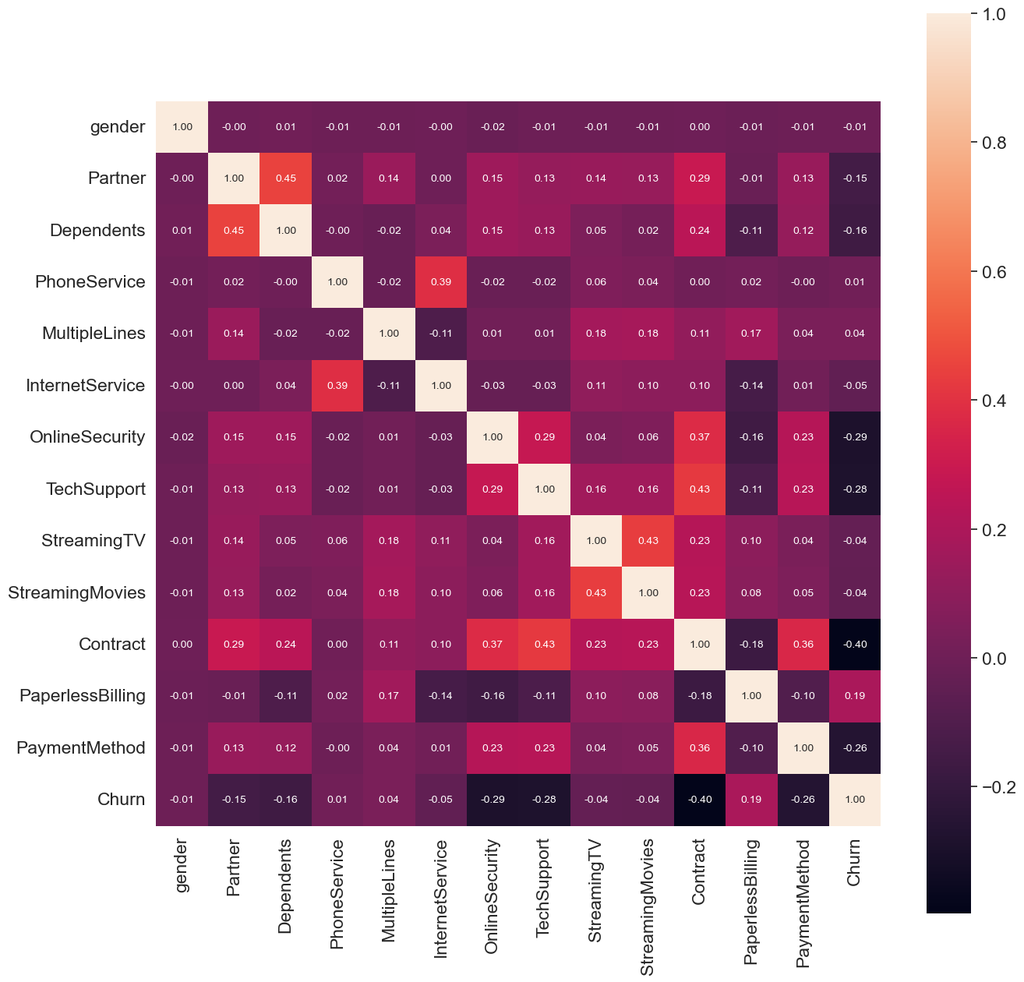

```python
# Using a correlation table,

corr_mat = df1.corr()

plt.figure(figsize =(15,15))

sns.heatmap(corr_mat, cbar=True, annot=True, square=True, fmt='.2f',annot_kws={'size':10})
```

## Supervised Machine Learning is suitable for this task

```python
# i will import the necessary libaries i need here now.
```

```python
#Data Preprossesing
from sklearn.model_selection import train_test_split
from sklearn.preprocessing import MinMaxScaler # to normalise my data in cases of outliers between 0 and 1

#classifier Libraries for Machine learning algorithm
from sklearn.linear_model import SGDClassifier
from sklearn.neighbors import KNeighborsClassifier
from sklearn.ensemble import RandomForestClassifier
from sklearn.linear_model import LogisticRegression

from sklearn.svm import LinearSVC, SVC
from sklearn.naive_bayes import GaussianNB
from sklearn.svm import SVC
from sklearn.tree import DecisionTreeClassifier
#pip install xgboost if not available
from xgboost import XGBClassifier

#Evaluation Metrics
from sklearn.metrics import accuracy_score, precision_score, recall_score, f1_score, roc_auc_score
from sklearn.metrics import confusion_matrix
```

#### Feature engineering and Data Preprocessing

```python
# Convert the 'label' column to an integer
#df['Churn'] = df['Churn'].astype('int')
churn_mapping = {'Yes': 1, 'No': 0}
df['Churn'] = df['Churn'].map(churn_mapping).astype(int)
```

```python
# The Total Charges contain 11 empty rows
# i need to replace the missing values with the Median
#calculate the median

df['TotalCharges'].median()
```

```
1397.475
```

```python
#Then I write the code to fill the missing values with the medican

df['TotalCharges'].fillna("1397.475", inplace=True)
```

```python
df2 = df[['gender', 'SeniorCitizen', 'Partner', 'Dependents', 'tenure', 'PhoneService', 'MultipleLines', 'InternetService', 'OnlineSecurity', 'DeviceProtection', 'TechSupport', 'StreamingTV', 'StreamingMovies', 'Contract', 'PaperlessBilling', 'PaymentMethod', 'MonthlyCharges', 'TotalCharges' ]]

label = df[['Churn']]
```

```python
df2.dtypes
```

```
gender                int32
SeniorCitizen         int64
Partner               int32
Dependents            int32
tenure                int64
PhoneService          int32
MultipleLines         int32
InternetService       int32
OnlineSecurity        int32
DeviceProtection      int32
TechSupport           int32
StreamingTV           int32
StreamingMovies       int32
Contract              int32
PaperlessBilling      int32
PaymentMethod         int32
MonthlyCharges      float64
TotalCharges         object
dtype: object
```

```python
# Replace any missing values with 0 or a specific value before conversion
# You can adjust the value to fill missing values as needed

df2['TotalCharges'].fillna(0, inplace=True)

# Convert the column to integer type
df2['TotalCharges'] = df2['TotalCharges'].astype(float)
```

```python
df2.dtypes
```

```
gender                int32
SeniorCitizen         int64
Partner               int32
Dependents            int32
tenure                int64
PhoneService          int32
MultipleLines         int32
InternetService       int32
OnlineSecurity        int32
DeviceProtection      int32
TechSupport           int32
StreamingTV           int32
StreamingMovies       int32
Contract              int32
PaperlessBilling      int32
PaymentMethod         int32
MonthlyCharges      float64
TotalCharges        float64
dtype: object
```

```python
# Changing my categorical variables to numerical variables

encoder = LabelEncoder() # method initialisation

# Looping for columns except columns with int or float

for c in df2.columns[0:]: #it is indexing the column one after the other, rather than using data1.column()
    if (df2[c].dtype == 'object'):
        df2[c] = encoder.fit_transform(df2[c])
    else:
        df2[c] = df2[c]


df2.head()
```

|  | gender | SeniorCitizen | Partner | Dependents | tenure | PhoneService | MultipleLines | InternetService | OnlineSecurity | DeviceProtection | TechSupport | StreamingTV | StreamingMovies | Contract | PaperlessBilling | PaymentMethod | MonthlyCharges | TotalCharges |
| --- | --- | --- | --- | --- | --- | --- | --- | --- | --- | --- | --- | --- | --- | --- | --- | --- | --- | --- |
| 0 | 0 | 0 | 1 | 0 | 1 | 0 | 1 | 0 | 0 | 0 | 0 | 0 | 0 | 0 | 1 | 0 | 29.85 | 29.85 |
| 1 | 1 | 0 | 0 | 0 | 34 | 1 | 0 | 0 | 2 | 2 | 0 | 0 | 0 | 1 | 0 | 1 | 56.95 | 1889.50 |
| 2 | 1 | 0 | 0 | 0 | 2 | 1 | 0 | 0 | 2 | 0 | 0 | 0 | 0 | 0 | 1 | 1 | 53.85 | 108.15 |
| 3 | 1 | 0 | 0 | 0 | 45 | 0 | 1 | 0 | 2 | 2 | 2 | 0 | 0 | 1 | 0 | 2 | 42.30 | 1840.75 |
| 4 | 0 | 0 | 0 | 0 | 2 | 1 | 0 | 1 | 0 | 0 | 0 | 0 | 0 | 0 | 1 | 0 | 70.70 | 151.65 |

i will be dropping off Customer ID and monthly group. I do not need them in my ML work

```python
label.head()
```

|  | Churn |
| --- | --- |
| 0 | 0 |
| 1 | 0 |
| 2 | 1 |
| 3 | 0 |
| 4 | 1 |

```python
#df2.dtypes # we only work with int or float with ML, Object will not work well with ML
```

All data type is now Integer or float

```python
# from my EDA, there was no significan outliers, however, i am still going to run my data with MinMaxScaler for double check.
# I need to test the data with and without outliers
# using normalisation and MinMaxScaler to make all the values between zero and one

scaler = MinMaxScaler()

df2['Scaled_tenure'] = scaler.fit_transform(df2['tenure'].values.reshape(-1, 1))
df2['Scaled_monthlycharges'] = scaler.fit_transform(df2['MonthlyCharges'].values.reshape(-1, 1))
df2['Scaled_totalcharges'] = scaler.fit_transform(df2['TotalCharges'].values.reshape(-1, 1))


df2.head()
```

|  | gender | SeniorCitizen | Partner | Dependents | tenure | PhoneService | MultipleLines | InternetService | OnlineSecurity | DeviceProtection | ... | StreamingTV | StreamingMovies | Contract | PaperlessBilling | PaymentMethod | MonthlyCharges | TotalCharges | Scaled_tenure | Scaled_monthlycharges | Scaled_totalcharges |
| --- | --- | --- | --- | --- | --- | --- | --- | --- | --- | --- | --- | --- | --- | --- | --- | --- | --- | --- | --- | --- | --- |
| 0 | 0 | 0 | 1 | 0 | 1 | 0 | 1 | 0 | 0 | 0 | ... | 0 | 0 | 0 | 1 | 0 | 29.85 | 29.85 | 0.013889 | 0.115423 | 0.001275 |
| 1 | 1 | 0 | 0 | 0 | 34 | 1 | 0 | 0 | 2 | 2 | ... | 0 | 0 | 1 | 0 | 1 | 56.95 | 1889.50 | 0.472222 | 0.385075 | 0.215867 |
| 2 | 1 | 0 | 0 | 0 | 2 | 1 | 0 | 0 | 2 | 0 | ... | 0 | 0 | 0 | 1 | 1 | 53.85 | 108.15 | 0.027778 | 0.354229 | 0.010310 |
| 3 | 1 | 0 | 0 | 0 | 45 | 0 | 1 | 0 | 2 | 2 | ... | 0 | 0 | 1 | 0 | 2 | 42.30 | 1840.75 | 0.625000 | 0.239303 | 0.210241 |
| 4 | 0 | 0 | 0 | 0 | 2 | 1 | 0 | 1 | 0 | 0 | ... | 0 | 0 | 0 | 1 | 0 | 70.70 | 151.65 | 0.027778 | 0.521891 | 0.015330 |

5 rows × 21 columns

The values of the Scaled data is done, let us drop off unscaled data

```python
df2.drop(['tenure', 'MonthlyCharges', 'TotalCharges'],axis=1, inplace = True)
df2.head()
```

|  | gender | SeniorCitizen | Partner | Dependents | PhoneService | MultipleLines | InternetService | OnlineSecurity | DeviceProtection | TechSupport | StreamingTV | StreamingMovies | Contract | PaperlessBilling | PaymentMethod | Scaled_tenure | Scaled_monthlycharges | Scaled_totalcharges |
| --- | --- | --- | --- | --- | --- | --- | --- | --- | --- | --- | --- | --- | --- | --- | --- | --- | --- | --- |
| 0 | 0 | 0 | 1 | 0 | 0 | 1 | 0 | 0 | 0 | 0 | 0 | 0 | 0 | 1 | 0 | 0.013889 | 0.115423 | 0.001275 |
| 1 | 1 | 0 | 0 | 0 | 1 | 0 | 0 | 2 | 2 | 0 | 0 | 0 | 1 | 0 | 1 | 0.472222 | 0.385075 | 0.215867 |
| 2 | 1 | 0 | 0 | 0 | 1 | 0 | 0 | 2 | 0 | 0 | 0 | 0 | 0 | 1 | 1 | 0.027778 | 0.354229 | 0.010310 |
| 3 | 1 | 0 | 0 | 0 | 0 | 1 | 0 | 2 | 2 | 2 | 0 | 0 | 1 | 0 | 2 | 0.625000 | 0.239303 | 0.210241 |
| 4 | 0 | 0 | 0 | 0 | 1 | 0 | 1 | 0 | 0 | 0 | 0 | 0 | 0 | 1 | 0 | 0.027778 | 0.521891 | 0.015330 |

# Machine Learning

```python
df2.info()
```

```
<class 'pandas.core.frame.DataFrame'>
RangeIndex: 7043 entries, 0 to 7042
Data columns (total 18 columns):
 #   Column                 Non-Null Count  Dtype
---  ------                 --------------  -----
 0   gender                 7043 non-null   int32
 1   SeniorCitizen          7043 non-null   int64
 2   Partner                7043 non-null   int32
 3   Dependents             7043 non-null   int32
 4   PhoneService           7043 non-null   int32
 5   MultipleLines          7043 non-null   int32
 6   InternetService        7043 non-null   int32
 7   OnlineSecurity         7043 non-null   int32
 8   DeviceProtection       7043 non-null   int32
 9   TechSupport            7043 non-null   int32
 10  StreamingTV            7043 non-null   int32
 11  StreamingMovies        7043 non-null   int32
 12  Contract               7043 non-null   int32
 13  PaperlessBilling       7043 non-null   int32
 14  PaymentMethod          7043 non-null   int32
 15  Scaled_tenure          7043 non-null   float64
 16  Scaled_monthlycharges  7043 non-null   float64
 17  Scaled_totalcharges    7043 non-null   float64
dtypes: float64(3), int32(14), int64(1)
memory usage: 605.4 KB
```

```python
missing_values_count = df2.isna().sum()
print(missing_values_count)
```

```
gender                   0
SeniorCitizen            0
Partner                  0
Dependents               0
PhoneService             0
MultipleLines            0
InternetService          0
OnlineSecurity           0
DeviceProtection         0
TechSupport              0
StreamingTV              0
StreamingMovies          0
Contract                 0
PaperlessBilling         0
PaymentMethod            0
Scaled_tenure            0
Scaled_monthlycharges    0
Scaled_totalcharges      0
dtype: int64
```

```python
# Replace 'column_name' with the name of the column containing NaN values
# Drop rows with NaN values in the specified column

#df2 = df2.dropna(subset=['Scaled_totalcharges'])
```

```python
#df2['Scaled_totalcharges'].nunique()
```

```python
#df2['Scaled_totalcharges'].sum()
```

```python
# Split the data set into training and testing sets - X = Questions, y = Answers

# xtrain and y train go together, x test and y test go together

# X_train are practice questions, Y train is your answer to the practice question

# X_test is the exam for ML, and y_test is the answer to cross check (label)

X_train, X_test, y_train, y_test, = train_test_split(df2, label, test_size = 0.2, random_state=45)
```

```python
# Remove rows with NaN values from X_train and y_train
#X_train = X_train.dropna()
#y_train = y_train[X_train.index]

# Remove rows with NaN values from X_test and y_test
#X_test = X_test.dropna()
#y_test = y_test[X_test.index]
```

After executing this line of code, `X_train` and `y_train` will contain the training features and labels, respectively, and `X_test` and `y_test` will contain the testing features and labels. You can then use these variables to train and evaluate your machine learning models.

```python
#df2.isna().sum()
```

```python
df2.shape
```

```
(7043, 18)
```

```python
label.shape
```

```
(7043, 1)
```

```python
X_train.head(2) # Practise question for ML
```

[output not shown]

```python
y_train.head(2)
```

|  | Churn |
| --- | --- |
| 4922 | 0 |
| 2512 | 0 |

```python
X_test.head(3)
```

|  | gender | SeniorCitizen | Partner | Dependents | PhoneService | MultipleLines | InternetService | OnlineSecurity | DeviceProtection | TechSupport | StreamingTV | StreamingMovies | Contract | PaperlessBilling | PaymentMethod | Scaled_tenure | Scaled_monthlycharges | Scaled_totalcharges |
| --- | --- | --- | --- | --- | --- | --- | --- | --- | --- | --- | --- | --- | --- | --- | --- | --- | --- | --- |
| 5851 | 0 | 1 | 0 | 0 | 1 | 2 | 1 | 2 | 2 | 2 | 2 | 2 | 1 | 1 | 2 | 0.486111 | 0.920896 | 0.440515 |
| 843 | 0 | 0 | 0 | 0 | 0 | 1 | 0 | 2 | 0 | 0 | 0 | 0 | 0 | 1 | 2 | 0.180556 | 0.125373 | 0.043307 |
| 5442 | 0 | 0 | 0 | 1 | 1 | 2 | 2 | 1 | 1 | 1 | 1 | 1 | 2 | 1 | 3 | 0.847222 | 0.067164 | 0.170730 |

```python
y_test.head(3)
```

|  | Churn |
| --- | --- |
| 5851 | 0 |
| 843 | 0 |
| 5442 | 0 |

###### Logistic Regression Model

```python
# Model Building

# Logistic Regression

logreg = LogisticRegression()

logreg.fit(X_train, y_train) # machine learning code for the ML Practice/training

ly_pred = logreg.predict(X_test) # ML code for the ML to predict

print ('Logistic Regression')
print ('Accurracy:', accuracy_score(y_test, ly_pred))
print ('Precision:', precision_score(y_test, ly_pred))
print ('Recall:', recall_score(y_test, ly_pred))
print ('F1-score:', f1_score(y_test, ly_pred))
print ('AUC-ROC:', roc_auc_score(y_test, ly_pred))
```

```
Logistic Regression
Accurracy: 0.8204400283889283
Precision: 0.6666666666666666
Recall: 0.56657223796034
F1-score: 0.6125574272588055
AUC-ROC: 0.7359376341316851
```

1. **Logistic Regression**: This is the type of classification model that was used for prediction.
2. **Accuracy**: An accuracy score of approximately 0.8204 (or 82.04%) suggests that the Logistic Regression model correctly predicts the outcomes for about 82% of the instances.
3. **Precision**: A precision of approximately 0.6667 (or 66.67%) indicates that among all instances predicted as positive, about 66.67% were actually positive. This metric emphasizes how well the model identifies positive instances accurately.
4. **Recall**: A recall of approximately 0.5666 (or 56.66%) indicates that the model captures about 56.66% of the actual positive instances. It represents the model's ability to identify positive instances among all the true positives.
5. **F1-score**: With an F1-score of approximately 0.6126 (or 61.26%), the model achieves a balanced measure that considers both precision and recall. It is the harmonic mean of these two metrics and indicates an overall performance trade-off between them.
6. **AUC-ROC**: An AUC-ROC value of approximately 0.7359 indicates that the model's Receiver Operating Characteristic (ROC) curve has a moderate degree of separation between true positive rate and false positive rate. This metric assesses the model's ability to distinguish between positive and negative instances.

```python
X_test.head(2) # the table that ML predicted
```

|  | gender | SeniorCitizen | Partner | Dependents | PhoneService | MultipleLines | InternetService | OnlineSecurity | DeviceProtection | TechSupport | StreamingTV | StreamingMovies | Contract | PaperlessBilling | PaymentMethod | Scaled_tenure | Scaled_monthlycharges | Scaled_totalcharges |
| --- | --- | --- | --- | --- | --- | --- | --- | --- | --- | --- | --- | --- | --- | --- | --- | --- | --- | --- |
| 5851 | 0 | 1 | 0 | 0 | 1 | 2 | 1 | 2 | 2 | 2 | 2 | 2 | 1 | 1 | 2 | 0.486111 | 0.920896 | 0.440515 |
| 843 | 0 | 0 | 0 | 0 | 0 | 1 | 0 | 2 | 0 | 0 | 0 | 0 | 0 | 1 | 2 | 0.180556 | 0.125373 | 0.043307 |

```python
ly_pred #the predition of X-test (the Machine learning Algorithm) for the target whether they have Heart disease or not
```

```
array([0, 0, 0, ..., 0, 1, 0])
```

```python
y_test
# the true answer that we have on the table where we can compare our "ly_pred" prediction on to check the accuracy or precision
```

|  | Churn |
| --- | --- |
| 5851 | 0 |
| 843 | 0 |
| 5442 | 0 |
| 4792 | 1 |
| 2303 | 1 |
| ... | ... |
| 459 | 0 |
| 710 | 1 |
| 1955 | 0 |
| 5956 | 1 |
| 2628 | 0 |

1409 rows × 1 columns

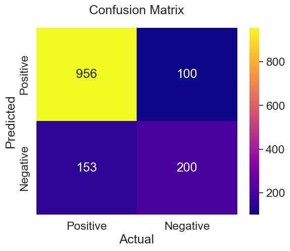

```python
# I am using the Confusion Matrix for Logistic Regression in ML

# Assuming you have defined y_test and ly_pred
lcm = confusion_matrix(y_test, ly_pred)  # Confusion matrix

# Create the heatmap with labels and tick labels
sns.heatmap(lcm, annot=True, cmap='plasma', fmt='g', xticklabels=['Positive', 'Negative'], yticklabels=['Positive', 'Negative'])
plt.xlabel('Actual')
plt.ylabel('Predicted')
plt.title('Confusion Matrix', y=1.05) #loc='bottom')  # Move the title to the left side
plt.show()
```

- Accuracy: (TP + TN) / (TP + TN + FP + FN), the proportion of correctly predicted instances among all instances.
- Precision: TP / (TP + FP), the proportion of true positive predictions among all positive predictions made by the model.
- Recall (Sensitivity or True Positive Rate): TP / (TP + FN), the proportion of actual positive instances that were correctly predicted by the model.
- Specificity: TN / (TN + FP), the proportion of actual negative instances that were correctly predicted by the model.
- F1-score: 2 *(Precision* Recall) / (Precision + Recall), a balanced measure that combines precision and recall.
- ROC curve and AUC-ROC: A graphical representation of the model's trade-off between true positive rate and false positive rate for different threshold values.

##### Random Forest

```python
# Using the random forest modeling for prediction

# Random Forest Classifier

rfc = RandomForestClassifier()
rfc.fit(X_train, y_train)
rfy_pred = rfc.predict(X_test)

print ('Random Classifier')
print ('Accurracy:', accuracy_score(y_test, rfy_pred))
print ('Precision:', precision_score(y_test, rfy_pred))
print ('Recall:', recall_score(y_test, rfy_pred))
print ('F1-score:', f1_score(y_test, rfy_pred))
print ('AUC-ROC:', roc_auc_score(y_test, rfy_pred))
```

```
Random Classifier
Accurracy: 0.808374733853797
Precision: 0.6378737541528239
Recall: 0.5439093484419264
F1-score: 0.5871559633027523
AUC-ROC: 0.7203448257361147
```

1. **Random Classifier**: This line indicates that the results correspond to the evaluation of a model that uses the Random Classifier algorithm.
2. **Accuracy**: An accuracy score of approximately 0.8084 (or 80.84%) suggests that the Random Classifier model correctly predicts the outcomes for about 80.84% of the instances in the dataset.
3. **Precision**: A precision of approximately 0.6379 (or 63.79%) indicates that among all instances predicted as positive by the model, about 63.79% were actually positive. This metric emphasizes how well the model identifies positive instances accurately.
4. **Recall**: A recall of approximately 0.5439 (or 54.39%) indicates that the model captures about 54.39% of the actual positive instances. It represents the model's ability to identify positive instances among all the true positive instances.
5. **F1-score**: With an F1-score of approximately 0.5872 (or 58.72%), the model achieves a balanced measure that considers both precision and recall. It is the harmonic mean of these two metrics and indicates an overall performance trade-off between them.
6. **AUC-ROC**: An AUC-ROC value of approximately 0.7203 suggests that the model's Receiver Operating Characteristic (ROC) curve has a moderate degree of separation between true positive rate and false positive rate. This metric assesses the model's ability to distinguish between positive and negative instances.

[figure not shown]

```python
# Creating a confusion Matrix for Random Forest Classifier

# I am using the Confusion Matrix for Logistic Regression in ML
rcm = confusion_matrix(y_test, rfy_pred)  # rcm = Random Confusion matrix

# Create the heatmap with labels and tick labels
sns.heatmap(rcm, annot=True, cmap='plasma', fmt='g', xticklabels=['Positive', 'Negative'], yticklabels=['Positive', 'Negative'])
plt.xlabel('Actual')
plt.ylabel('Predicted')
plt.title('Confusion Matrix', y=1.05) #loc='bottom')  # Move the title to the left side
plt.show()
```

Accuracy: (TP + TN) / (TP + TN + FP + FN), the proportion of correctly predicted instances among all instances.

Precision: TP / (TP + FP), the proportion of true positive predictions among all positive predictions made by the model.

Recall (Sensitivity or True Positive Rate): TP / (TP + FN), the proportion of actual positive instances that were correctly predicted by the model.

Specificity: TN / (TN + FP), the proportion of actual negative instances that were correctly predicted by the model.

F1-score: 2 *(Precision* Recall) / (Precision + Recall), a balanced measure that combines precision and recall.

ROC curve and AUC-ROC: A graphical representation of the model's trade-off between true positive rate and false positive rate for different threshold values.

##### KNeighbor Classifier

```python
# Using the KNeighbor modeling for prediction

knc = KNeighborsClassifier()
knc.fit(X_train, y_train)
kdy_pred = knc.predict(X_test)

print (' KNeighbor Classifier ')
print ('Accurracy:', accuracy_score(y_test, kdy_pred))
print ('Precision:', precision_score(y_test, kdy_pred))
print ('Recall:', recall_score(y_test, kdy_pred))
print ('F1-score:', f1_score(y_test, kdy_pred))
print ('AUC-ROC:', roc_auc_score(y_test, kdy_pred))
```

```
 KNeighbor Classifier
Accurracy: 0.7757274662881476
Precision: 0.5555555555555556
Recall: 0.5240793201133145
F1-score: 0.5393586005830905
AUC-ROC: 0.6919639024808997
```

[figure not shown]

```python
# Creating a confusion Matrix for KNieghbor Classifier

# I am using the Confusion Matrix for KNeighbor in ML
km = confusion_matrix(y_test, kfy_pred)  # km = KNeighbor matrix

# Create the heatmap with labels and tick labels
sns.heatmap(km, annot=True, cmap='plasma', fmt='g', xticklabels=['Positive', 'Negative'], yticklabels=['Positive', 'Negative'])
plt.xlabel('Actual')
plt.ylabel('Predicted')
plt.title('Confusion Matrix', y=1.05) #loc='bottom')  # Move the title to the left side
plt.show()
```

Accuracy: (TP + TN) / (TP + TN + FP + FN), the proportion of correctly predicted instances among all instances.

Precision: TP / (TP + FP), the proportion of true positive predictions among all positive predictions made by the model.

Recall (Sensitivity or True Positive Rate): TP / (TP + FN), the proportion of actual positive instances that were correctly predicted by the model.

Specificity: TN / (TN + FP), the proportion of actual negative instances that were correctly predicted by the model.

F1-score: 2 *(Precision* Recall) / (Precision + Recall), a balanced measure that combines precision and recall.

ROC curve and AUC-ROC: A graphical representation of the model's trade-off between true positive rate and false positive rate for different threshold values.

##### SGD Classisfier

```python
# Using the SGDClassisfier modeling for prediction

# SGDClassisfier

sdc = SGDClassifier()
sdc.fit(X_train, y_train)
sdy_pred = sdc.predict(X_test)

print ('SGD Classisfier ')
print ('Accurracy:', accuracy_score(y_test, sdy_pred))
print ('Precision:', precision_score(y_test, sdy_pred))
print ('Recall:', recall_score(y_test, sdy_pred))
print ('F1-score:', f1_score(y_test, sdy_pred))
print ('AUC-ROC:', roc_auc_score(y_test, sdy_pred))
```

```
SGD Classisfier
Accurracy: 0.815471965933286
Precision: 0.6666666666666666
Recall: 0.5269121813031161
F1-score: 0.5886075949367088
AUC-ROC: 0.7194219997424671
```

1. **SGD Classifier**: This line indicates that the results correspond to the evaluation of a model that uses the SGD (Stochastic Gradient Descent) Classifier algorithm.
2. **Accuracy**: An accuracy score of approximately 0.8155 (or 81.55%) suggests that the SGD Classifier model correctly predicts the outcomes for about 81.55% of the instances in the dataset.
3. **Precision**: A precision of approximately 0.6667 (or 66.67%) indicates that among all instances predicted as positive by the model, about 66.67% were actually positive. This metric emphasizes how well the model identifies positive instances accurately.
4. **Recall**: A recall of approximately 0.5269 (or 52.69%) indicates that the model captures about 52.69% of the actual positive instances. It represents the model's ability to identify positive instances among all the true positive instances.
5. **F1-score**: With an F1-score of approximately 0.5886 (or 58.86%), the model achieves a balanced measure that considers both precision and recall. It is the harmonic mean of these two metrics and indicates an overall performance trade-off between them.
6. **AUC-ROC**: An AUC-ROC value of approximately 0.7194 suggests that the model's Receiver Operating Characteristic (ROC) curve has a moderate degree of separation between true positive rate and false positive rate. This metric assesses the model's ability to distinguish between positive and negative instances.

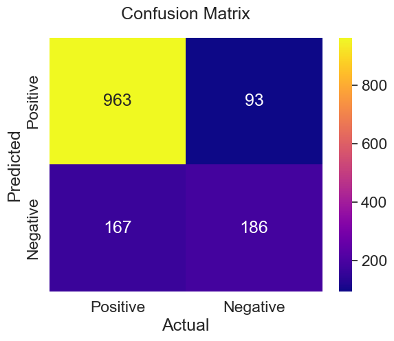

```python
# Creating a confusion Matrix for SGD CLassisfier Classifier

# I am using the Confusion Matrix for SGD Classisfier in ML
sg = confusion_matrix(y_test, sdy_pred)  # sg = SGD CLassisfier

# Create the heatmap with labels and tick labels
sns.heatmap(sg, annot=True, cmap='plasma', fmt='g', xticklabels=['Positive', 'Negative'], yticklabels=['Positive', 'Negative'])
plt.xlabel('Actual')
plt.ylabel('Predicted')
plt.title('Confusion Matrix', y=1.05) #loc='bottom')  # Move the title to the left side
plt.show()
```

Accuracy: (TP + TN) / (TP + TN + FP + FN), the proportion of correctly predicted instances among all instances.

Precision: TP / (TP + FP), the proportion of true positive predictions among all positive predictions made by the model.

Recall (Sensitivity or True Positive Rate): TP / (TP + FN), the proportion of actual positive instances that were correctly predicted by the model.

Specificity: TN / (TN + FP), the proportion of actual negative instances that were correctly predicted by the model.

F1-score: 2 *(Precision* Recall) / (Precision + Recall), a balanced measure that combines precision and recall.

ROC curve and AUC-ROC: A graphical representation of the model's trade-off between true positive rate and false positive rate for different threshold values.